# Text mining di alcuni articoli sulla guerra Russia-Ucraina

Alessio Pio Gennaro

2022-05-23

Questa prima parte copre un aspetto molto importante dell’analisi, ovvero il processo di estrazione di testo da pagine web o documenti. Di solito è chiamato *Crawling* l’insieme di tecniche per il download automatico di pagine web.

Al contrario, il processo di estrazione di dati testuali o metadati prende il nome di *Scraping*. Utilizziamo il package `rvest` con il supporto di [phantomJS](https://phantomjs.org/)

```r
# install.packages("rvest")
# install.packages("webdriver")

options(stringsAsFactors = F)

library(dplyr)
library(ggraph)
library(ggplot2)
library(igraph)
library(lubridate)
library(tidyr)
library(tidytext)
library(webdriver)
library(readr)
library(rvest)
library(stringr)
library(wordcloud)
library(widyr)

# install_phantomjs()

require(webdriver)

pjs_instance <- run_phantomjs("ERROR")
pjs_session <- Session$new(port = pjs_instance$port)

replace_na <- function(string) {
  if (is.na(string)) {
    return("")
  }
  return(string)
}
```

## Getting the feet wet

Facciamo subito un test.

```r
url <- "https://www.theguardian.com/world/2017/jun/26/angela-merkel-and-donald-trump-head-for-clash-at-g20-summit"

# caricamento dell'url nella sessione phantomJS
pjs_session$go(url)

# download del codice della pagina
rendered_source <- pjs_session$getSource()

# parsing del contenuto scaricato
html_document <- read_html(rendered_source)

html_document
```

```
## {html_document}
## <html lang="en" style="">
## [1] <head>\n<meta http-equiv="Content-Type" content="text/html; charset=UTF-8 ...
## [2] <body style="">\n                <a href="#maincontent" class="dcr-1y2qbj ...
```

```r
# eventualmente
# html_document <- read_html(url)
```

Adesso che abbiamo a disposizione una pagina HTML cerchiamo di estrapolare informazioni dai tag.

```r
title_xpath <- "//div[contains(@data-gu-name, 'headline')]//h1"

title_text <- html_document %>%
  html_element(xpath = title_xpath) %>%
  html_text(trim = TRUE)

cat(title_text)
```

```
## Angela Merkel and Donald Trump head for clash at G20 summit
```

```r
intro_xpath <- "//div[contains(@data-gu-name, 'standfirst')]//p"

intro_text <- html_document %>%
  html_element(xpath = intro_xpath) %>%
  html_text(trim = TRUE)

cat(intro_text)
```

```
## German chancellor plans to make climate change, free trade and mass migration key themes in Hamburg, putting her on collision course with US
```

```r
body_xpath <- "//div[contains(@class, 'article-body')]//p"

body_text <- html_document %>%
  html_elements(xpath = body_xpath) %>%
  html_text(trim = TRUE) %>%
  paste0(collapse = "\n")

cat(body_text)
```

```
## A clash between Angela Merkel and Donald Trump appears unavoidable after Germany signalled that it will make climate change, free trade and the management of forced mass global migration the key themes of the G20 summit in Hamburg next week.
## The G20 summit brings together the world’s biggest economies, representing 85% of global gross domestic product (GDP), and Merkel’s chosen agenda looks likely to maximise American isolation while attempting to minimise disunity amongst others.
## The meeting, which is set to be the scene of large-scale street protests, will also mark the first meeting between Trump and the Russian president, Vladimir Putin, as world leaders.
## Trump has already rowed with Europe once over climate change and refugees at the G7 summit in Italy, and now looks set to repeat the experience in Hamburg but on a bigger stage, as India and China join in the criticism of Washington.
## Last week, the new UN secretary-general, António Guterres, warned the Trump team if the US disengages from too many issues confronting the international community it will be replaced as world leader.
## On climate change, Merkel has prepared the ground carefully, hosting in Berlin the two allies she most needs – the Indian prime minister, Narendra Modi, and the Chinese premier, Li Keqiang.
## China is the single largest emitter of carbon, and India the third. If they followed America in rejecting the Paris agreement, the whole process would unravel. Both countries have said they will not pull out of the treaty, and will beat their Paris commitments.
## Germany insists it is not seeking confrontation at the summit. Sigmar Gabriel, the German foreign minister, points out there will be many far more rightwing governments present in Hamburg than Trump, and they will receive far less obloquy from the expected tens of thousands of street protesters.
## Nor does he pretend his country wishes to set itself up as a rival to America, saying Germany has got enough responsibilities already. “As German foreign minister, you wake up in the morning with a demand for leadership, and in the evening you go to bed with it,” Gabriel said.
## Merkel is reluctant to be cast in the role of leader of western liberal vales, although a poll published last week by Pew Research found Merkel’s favourability ratings on the rise, especially on the left, with an impressive 52% of all Europeans surveyed confident she would “do the right thing in …
## But the G7, and Trump’s subsequent decision to shun the Paris climate change treaty, clearly left a permanent mark on her, leading to her famous declaration of independence four days later at a Christian Social Union (CSU) rally in a Bavarian beer tent. In remarks seen in the US as marking a new …
## European voters’ decisions to give a commanding parliamentary majority to Emmanuel Macron, and not to provide the same to Theresa May, will have confirmed Merkel’s belief that Europe once again can be master of its own fate.
## The fact that the only country Trump will visit in Europe before the G20 is Poland – the bad boy of Europe and its greatest carbon emitter –is symbolic of a president uneasy with Europe’s new confidence. Poland and Trump also both oppose Russia’s Nord Stream 2 pipeline, due to double the amount o…
## On protectionism, Merkel was blunt in speaking to German business this week about her belief in open markets. “We’ll do all we can to get as broad an agreement on this as possible in Hamburg. Given the new American administration that’s not easy, but nonetheless we need to make the effort.”
## But Europe’s leaders are not the only ones re-evaluating their relationship with the US. The Canadian foreign minister, Chrystia Freeland, told her parliament last week the fact that the US, under its new administration, “has come to question the very worth of its mantle of global leadership”, me…
## Australia’s foreign minister, Julie Bishop, in March claimed many regional partners were locked in a “strategic holding pattern”, waiting to see where Trump will go.
## Argentina, the next host of the G20, has also told Trump that it has tried isolation and it does not work.
## So at the broadest level, the G20 summit will be a first test of whether other leaders can, or indeed want to, escape from America’s shadow.
## But it is Merkel’s compact for Africa that most animates her, according to foreign ministers that have seen her recently.
## Merkel fears that long term demographic trends mean 100 m Africans could come to Europe driven by climate change, poverty, and Europe is wholly unprepared.
## Combating poverty upstream in Africa as a way to stem the mass migrant flow to Europe downstream is her guiding idea. Her specific initiative is to team up African nations which have committed to economic reforms with private investors who would then bring jobs and businesses.
```

```r
# typeof(body_text)
# class(body_text)
```

Infine aggiungiamo anche la data.

```r
# date_xpath <- "//time"
date_xpath <- "//meta[contains(@property, 'published_time')]"

date_object <- html_document %>%
  html_element(xpath = date_xpath) %>%
  html_attr(name = "content") %>%
  as.Date()

cat(format(date_object, "%Y-%m-%d"))
```

```
## 2017-06-26
```

```r
# typeof(date_object)
# class(date_object)
```

Di solito non vogliamo scaricare un solo documento ma una serie di documenti. Adesso vediamo come scaricare tutti gli articoli *taggati* con “Angela Merkel”. Potremmo anche essere interessati a salvare i risultati di un motore di ricerca, o di una qualunque collezione di link.

```r
url <- "https://www.theguardian.com/world/angela-merkel"

pjs_session$go(url)
rendered_source <- pjs_session$getSource()
html_document <- read_html(rendered_source)
```

Adesso siamo interessati ad effettuare il download di ogni articolo *linkato*. Per farlo, estraiamo tutti gli attributi `href` dagli elementi `a` che rientrano in una *classe CSS*.

```r
links <- html_document %>%
  html_elements(xpath = "//div[contains(@class, 'fc-item')]/a") %>%
  html_attr(name = "href")

head(links, 5)
```

```
## [1] "https://www.theguardian.com/world/2022/jun/07/no-regrets-over-handling-of-vladimir-putin-says-angela-merkel"
## [2] "https://www.theguardian.com/world/2022/jun/02/germany-dependence-russian-energy-gas-oil-nord-stream"
## [3] "https://www.theguardian.com/world/2022/may/20/chat-group-leak-reveals-far-right-fantasies-of-germany-afd"
## [4] "https://www.theguardian.com/commentisfree/2022/apr/17/observer-view-french-elections"
## [5] "https://www.theguardian.com/commentisfree/2022/apr/10/germany-role-against-delusional-putin#comments"
```

```r
page_numbers <- 1:8
base_url <- "https://www.theguardian.com/world/angela-merkel?page="
paging_urls <- paste0(base_url, page_numbers)

head(paging_urls, 3)

all_links <- NULL

for (url in paging_urls) {
  # download e parsing di una singola pagina web
  pjs_session$go(url)
  rendered_source <- pjs_session$getSource()
  html_document <- read_html(rendered_source)

  # parsing ed estrazione dei link
  links <- html_document %>%
    html_elements(xpath = "//div[contains(@class, 'fc-item')]/a") %>%
    html_attr(name = "href")

  all_links <- c(all_links, links)
}

head(all_links, 10)
length(all_links)
```

Combiniamo tutto in una funzione.

```r
scrape_guardian_article <- function(url) {

  pjs_session$go(url)
  rendered_source <- pjs_session$getSource()
  html_document <- read_html(rendered_source)

  title_xpath <- "//div[contains(@data-gu-name, 'headline')]//h1"
  title_text <- html_document %>%
    html_element(xpath = title_xpath) %>%
    html_text(trim = TRUE)

  intro_xpath <- "//div[contains(@data-gu-name, 'standfirst')]//p"
  intro_text <- html_document %>%
    html_element(xpath = intro_xpath) %>%
    html_text(trim = TRUE)

  body_xpath <- "//div[contains(@class, 'article-body')]//p"
  body_text <- html_document %>%
    html_elements(xpath = body_xpath) %>%
    html_text(trim = TRUE) %>%
    paste0(collapse = "\n")

  date_xpath <- "//meta[contains(@property, 'published_time')]"
  date_object <- html_document %>%
    html_element(xpath = date_xpath) %>%
    html_attr(name = "content") %>%
    as.Date()

  article <- data.frame(
    url = url,
    date = date_object,
    title = title_text,
    body = paste0(intro_text, "\n", body_text)
  )

  article
}

scrape_all_guardian_articles <- function(all_links) {

  all_articles <- data.frame()

  for (i in 1:length(all_links)) {
    cat("Downloading", i, "of", length(all_links), "URL:", all_links[i], "\n")
    article <- scrape_guardian_article(all_links[i])

    all_articles <- all_articles %>% bind_rows(article)
  }

  all_articles
}
```

```r
all_articles <- scrape_all_guardian_articles(all_links)
all_articles

write_csv2(all_articles, "./data/merkel_guardian.csv")
```

```r
all_articles <- read_csv2("data/merkel_guardian.csv")

all_articles
```

```
## # A tibble: 181 × 4
##    url                                                    date       title body
##    <chr>                                                  <date>     <chr> <chr>
##  1 https://www.theguardian.com/world/2022/jun/02/germany… 2022-06-02 <NA>  "Ger…
##  2 https://www.theguardian.com/world/2022/may/20/chat-gr… 2022-05-20 Chat… "Amo…
##  3 https://www.theguardian.com/commentisfree/2022/apr/17… 2022-04-17 The … "NA\…
##  4 https://www.theguardian.com/commentisfree/2022/apr/10… 2022-04-10 Germ… "Onl…
##  5 https://www.theguardian.com/commentisfree/2022/apr/10… 2022-04-10 Germ… "Onl…
##  6 https://www.theguardian.com/commentisfree/2022/apr/10… 2022-04-10 Germ… "Onl…
##  7 https://www.theguardian.com/world/2022/mar/05/germany… 2022-03-05 Germ… "The…
##  8 https://www.theguardian.com/commentisfree/2021/dec/26… 2021-12-26 Noth… "Thi…
##  9 https://www.theguardian.com/world/2021/dec/08/olaf-sc… 2021-12-08 Olaf… "For…
## 10 https://www.theguardian.com/world/2021/dec/08/after-1… 2021-12-08 Afte… "Whi…
## # … with 171 more rows
```

Adesso proviamo a fare la stessa cosa con un altro importante quotidiano, il [New York Times](https://www.nytimes.com).

```r
nyt_base_url <- "https://www.nytimes.com"

add_base_url <- function(link) {

  if (!str_detect(link, paste0("^", nyt_base_url))) {
    link <- paste0(nyt_base_url, link)
  } else {
    link <- link
  }

  link
}

filter_links <- function(all_links) {

  filtered <- NULL

  for (link in links) {
    if (!str_detect(link, "/es/") &&
        !str_detect(link, "/video/")) {
      correct <- add_base_url(link = link)
      filtered <- c(filtered, correct)
    }
  }
  filtered
}
```

```r
url <- "https://www.nytimes.com/topic/person/angela-merkel"

# download e parsing di una singola pagina web
pjs_session$go(url)
rendered_source <- pjs_session$getSource()
html_document <- read_html(rendered_source)

all_links <- NULL

link <- html_document %>%
  html_elements(xpath = "//li[contains(@class, 'css-ye6x8s')]//a") %>%
  html_attr(name = "href")

all_links <- c(all_links, link)
all_links <- filter_links(all_links = all_links)

all_links
length(all_links)
```

Adesso passiamo ad analizzare il [Los Angeles Times](https://www.latimes.com/).

```r
page_numbers <- 1:16
base_url <- "https://www.latimes.com/search?q=Merkel&p="
paging_urls <- paste0(base_url, page_numbers)

head(paging_urls, 3)
```

```
## [1] "https://www.latimes.com/search?q=Merkel&p=1"
## [2] "https://www.latimes.com/search?q=Merkel&p=2"
## [3] "https://www.latimes.com/search?q=Merkel&p=3"
```

```r
all_links <- NULL

for (url in paging_urls) {
  # download e parsing di una singola pagina web
  pjs_session$go(url)
  rendered_source <- pjs_session$getSource()
  html_document <- read_html(rendered_source)

  # parsing ed estrazione dei link
  links <- html_document %>%
    html_elements(xpath = "//div[contains(@class, 'promo-wrapper')]//a") %>%
    html_attr(name = "href")
  links <- unique(links)
  all_links <- c(all_links, links)
}

head(all_links, 10)
```

```
##  [1] "https://www.latimes.com/world-nation/story/2021-11-24/german-parties-deal-government-end-merkel-era"
##  [2] "https://www.latimes.com/world-nation"
##  [3] "https://www.latimes.com/world-nation/story/2021-12-08/scholz-succeeds-merkel-german-chancellor-new-era"
##  [4] "https://www.latimes.com/world-nation/story/2021-12-07/germany-angela-merkel-last-day-chancellor"
##  [5] "https://www.latimes.com/world-nation/story/2021-12-04/merkel-virus-death-toll-so-bitter-because-it-is-avoidable"
##  [6] "https://www.latimes.com/world-nation/story/2021-11-10/merkel-asks-putin-intervene-belarus-migrant-standoff"
##  [7] "https://www.latimes.com/world-nation/story/2021-09-24/germanys-angela-merkel-global-political-icon-prepares-to-exit-political-stage"
##  [8] "https://www.latimes.com/world-nation/story/2021-09-27/germany-tricky-search-post-merkel-government-coalition"
##  [9] "https://www.latimes.com/world-nation/story/2021-09-26/germany-election"
## [10] "https://www.latimes.com/world-nation/story/2021-07-18/merkel-tours-surreal-flood-scene-vows-aid-climate-action"
```

```r
length(all_links)
```

```
## [1] 203
```

```r
scrape_la_times_article <- function(url) {

  pjs_session$go(url)
  rendered_source <- pjs_session$getSource()
  html_document <- read_html(rendered_source)

  title_xpath <- "//title"
  title_text <- html_document %>%
    html_element(xpath = title_xpath) %>%
    html_text(trim = TRUE)

  body_xpath <- "//div[contains(@class, 'page-article-body')]//p"
  body_text <- html_document %>%
    html_elements(xpath = body_xpath) %>%
    html_text(trim = TRUE) %>%
    paste0(collapse = "\n")

  date_xpath <- "//time[contains(@class, 'published-date')]"
  date_object <- html_document %>%
    html_element(xpath = date_xpath) %>%
    html_attr(name = "datetime") %>%
    as.Date()

  article <- data.frame(
    url = url,
    date = date_object,
    title = title_text,
    body = body_text
  )

  article
}

scrape_all_la_times_articles <- function(all_links) {

  all_articles <- data.frame()

  for (i in 1:length(all_links)) {
    cat("Downloading", i, "of", length(all_links), "URL:", all_links[i], "\n")
    article <- scrape_la_times_article(all_links[i])

    all_articles <- all_articles %>% bind_rows(article)
  }

  all_articles
}
```

```r
all_articles <- scrape_all_la_times_articles(all_links)
all_articles

write_csv2(all_articles, "./data/merkel_la_times.csv")
```

```r
all_articles <- read_csv2("data/merkel_la_times.csv")

all_articles
```

Un’altra fonte potrebbe essere il [New York Post](https://nypost.com). Replichiamo quanto fatto sopra.

```r
page_numbers <- 1:8
base_url <- "https://nypost.com/search/Angela+Merkel/page/"
paging_urls <- paste0(base_url, page_numbers)

head(paging_urls, 3)

all_links <- NULL

for (url in paging_urls) {
  # download e parsing di una singola pagina web
  pjs_session$go(url)
  rendered_source <- pjs_session$getSource()
  html_document <- read_html(rendered_source)

  # parsing ed estrazione dei link
  links <- html_document %>%
    html_elements(xpath = "//a[contains(@class, 'postid')]") %>%
    html_attr(name = "href")

  all_links <- c(all_links, links)
}

head(all_links, 10)
length(all_links)
```

Non abbiamo avuto molta fortuna. Un’altra sorgente da analizzare è il [Wall Street Journal](https://www.wsj.com).

```r
page_numbers <- 1:9
base_url <- "https://www.wsj.com/search?query=Angela%20Merkel&mod=searchresults_viewallresults&page="
paging_urls <- paste0(base_url, page_numbers)

head(paging_urls, 3)

all_links <- NULL

for (url in paging_urls) {
  # download e parsing di una singola pagina web
  pjs_session$go(url)
  rendered_source <- pjs_session$getSource()
  html_document <- read_html(rendered_source)

  # parsing ed estrazione dei link
  links <- html_document %>%
    html_elements(xpath = "//article//div[contains(@class, 'WSJTheme--headline--7VCzo7Ay')]/h3/a") %>%
    html_attr(name = "href")

  all_links <- c(all_links, links)
}

head(all_links, 10)
length(all_links)
```

Tutti gli articoli sul sito web sono protetti da paywall. Niente da fare anche qui.

Proviamo con il [Metro](https://metro.co.uk).

```r
page_numbers <- 1
base_url <- "https://metro.co.uk/search/#gsc.tab=0&gsc.q=Angela%20Merkel&gsc.sort=date&gsc.page="
paging_urls <- paste0(base_url, page_numbers)

head(paging_urls, 3)

all_links <- NULL

for (url in paging_urls) {
  # download e parsing di una singola pagina web
  pjs_session$go(url)
  rendered_source <- pjs_session$getSource()
  html_document <- read_html(rendered_source)

  # parsing ed estrazione dei link
  links <- html_document %>%
    html_elements(xpath = "//a[@class='gs-title']") %>%
    html_attr(name = "href")

  all_links <- c(all_links, links)
}

head(all_links, 10)
length(all_links)
```

Passiamo alla [CNN](https://cnn.com).

```r
page_numbers <- 1
base_url <- "https://edition.cnn.com/search?q=Angela%20Merkel&size=10&sort=relevance&page="
paging_urls <- paste0(base_url, page_numbers)

head(paging_urls, 3)

all_links <- NULL

for (url in paging_urls) {
  # download e parsing di una singola pagina web
  pjs_session$go(url)
  rendered_source <- pjs_session$getSource()
  html_document <- read_html(rendered_source)

  # parsing ed estrazione dei link
  links <- html_document %>%
    html_elements(xpath = "//div[contains(@class, 'cnn-search__results-list')]//div")

  all_links <- c(all_links, links)
}

head(all_links, 10)
length(all_links)

all_links
```

Proviamo con il sito della [BBC](https://www.bbc.co.uk).

```r
page_numbers <- 1
base_url <- "https://www.bbc.co.uk/search?q=Angela+Merkel&page="
paging_urls <- paste0(base_url, page_numbers)

head(paging_urls, 3)
```

```
## [1] "https://www.bbc.co.uk/search?q=Angela+Merkel&page=1"
```

```r
all_links <- NULL

for (url in paging_urls) {
  # download e parsing di una singola pagina web
  pjs_session$go(url)
  rendered_source <- pjs_session$getSource()
  html_document <- read_html(rendered_source)

  # parsing ed estrazione dei link
  links <- html_document %>%
    html_elements(xpath = "//a[contains(@class, 'ssrcss-1ynlzyd-PromoLink')]") %>%
    html_attr(name = "href")

  all_links <- c(all_links, links)
}

head(all_links, 10)
```

```
##  [1] "https://www.bbc.co.uk/programmes/b0bvlbyx"
##  [2] "https://www.bbc.co.uk/programmes/n3ct5fvv"
##  [3] "https://www.bbc.co.uk/news/world-europe-61727450"
##  [4] "https://www.bbc.co.uk/news/world-europe-58662226"
##  [5] "https://www.bbc.co.uk/news/world-europe-59514304"
##  [6] "https://www.bbc.co.uk/news/world-europe-46022660"
##  [7] "https://www.bbc.co.uk/news/uk-politics-57699532"
##  [8] "https://www.bbc.co.uk/programmes/b09k6pn7"
##  [9] "https://www.bbc.co.uk/news/world-europe-58657354"
## [10] "https://www.bbc.co.uk/programmes/m0012145"
```

```r
length(all_links)
```

```
## [1] 10
```

```r
scrape_bbc_article <- function(url) {

  pjs_session$go(url)
  rendered_source <- pjs_session$getSource()
  html_document <- read_html(rendered_source)

  title_xpath <- "//h1[contains(@id, 'main-heading')]"
  title_text1 <- html_document %>%
    html_element(xpath = title_xpath) %>%
    html_text(trim = TRUE)

  title_xpath <- "//h1[contains(@class, 'no-margin')]"
  title_text2 <- html_document %>%
    html_element(xpath = title_xpath) %>%
    html_text(trim = TRUE)

  title_text1 <- replace_na(title_text1)
  title_text2 <- replace_na(title_text2)
  title_text <- paste0(title_text1, title_text2)

  body_xpath <- "//div[contains(@class, 'RichTextContainer')]//p"
  body_text <- html_document %>%
    html_elements(xpath = body_xpath) %>%
    html_text(trim = TRUE) %>%
    paste0(collapse = "\n")

  body_xpath <- "//div[contains(@class, 'RichTextComponentWrapper')]//p"
  body_text2 <- html_document %>%
    html_elements(xpath = body_xpath) %>%
    html_text(trim = TRUE) %>%
    paste0(collapse = "\n")

  body_xpath <- "//div[contains(@class, 'synopsis-toggle__long')]//p"
  body_text3 <- html_document %>%
    html_elements(xpath = body_xpath) %>%
    html_text(trim = TRUE) %>%
    paste0(collapse = "\n")

  body_text = paste0(replace_na(body_text), replace_na(body_text2), replace_na(body_text3))

  date_xpath <- "//time[contains(@data-testid, 'timestamp')]"
  date_object <- html_document %>%
    html_element(xpath = date_xpath) %>%
    html_attr(name = "datetime") %>%
    as.Date()

    article <- data.frame(
    url = url,
    date = date_object,
    title = title_text,
    body = body_text
  )

  article
}

scrape_all_bbc_articles <- function(all_links) {

  all_articles <- data.frame()

  for (i in 1:length(all_links)) {
    cat("Downloading", i, "of", length(all_links), "URL:", all_links[i], "\n")
    article <- scrape_bbc_article(all_links[i])

    all_articles <- all_articles %>% bind_rows(article)
  }

  all_articles
}
```

```r
all_articles <- scrape_all_bbc_articles(all_links)
all_articles

all_articles <- all_articles %>%
  filter(!is.na(date))

write_csv2(all_articles, "./data/merkel_bbc.csv")
```

```r
all_articles <- read_csv2("data/merkel_bbc.csv")

all_articles
```

Adesso tocca al [New Yorker](https://www.newyorker.com).

```r
page_numbers <- 1:18
begin_url <- "https://www.newyorker.com/search/q/Angela%20Merkel/page/"
end_url <- "/n,w"
paging_urls <- paste0(begin_url, page_numbers, end_url)

head(paging_urls, 3)
```

```
## [1] "https://www.newyorker.com/search/q/Angela%20Merkel/page/1/n,w"
## [2] "https://www.newyorker.com/search/q/Angela%20Merkel/page/2/n,w"
## [3] "https://www.newyorker.com/search/q/Angela%20Merkel/page/3/n,w"
```

```r
all_links <- NULL

for (url in paging_urls) {
  # download e parsing di una singola pagina web
  pjs_session$go(url)
  rendered_source <- pjs_session$getSource()
  html_document <- read_html(rendered_source)

  # parsing ed estrazione dei link
  links <- html_document %>%
    html_elements(xpath = "//div[contains(@class, 'River__riverItemContent___2hXMG')]/a[2]") %>%
    html_attr(name = "href")

  all_links <- c(all_links, links)
}

head(all_links, 10)
```

```
##  [1] "/news/news-desk/how-putins-invasion-of-ukraine-upended-germany"
##  [2] "/news/daily-comment/the-growing-fear-of-a-wider-war-between-russia-and-the-west"
##  [3] "/news/news-desk/a-migrant-prison-officially-closes-but-how-much-has-changed"
##  [4] "/news/daily-comment/emmanuel-macrons-overtures-to-vladimir-putin-and-the-race-to-prevent-war-in-ukraine"
##  [5] "/news/annals-of-inquiry/a-political-philosopher-is-hopeful-about-the-democrats"
##  [6] "/news/daily-comment/angela-merkel-leaves-politics-on-her-own-terms"
##  [7] "/news/daily-comment/pope-francis-and-joe-biden-will-meet-in-rome-but-not-alas-in-glasgow"
##  [8] "/news/daily-comment/what-is-going-on-with-the-german-election"
##  [9] "/humor/borowitz-report/fox-news-accuses-biden-of-using-federal-government-to-improve-country"
## [10] "/news/letter-from-bidens-washington/for-biden-trump-is-an-easy-act-to-follow-in-europe"
```

```r
length(all_links)
```

```
## [1] 180
```

```r
scrape_new_yorker_article <- function(url) {

  pjs_session$go(paste0("https://www.newyorker.com", url))
  rendered_source <- pjs_session$getSource()
  html_document <- read_html(rendered_source)

  title_xpath <- "//h1[contains(@data-testid, 'ContentHeaderHed')]"
  title_text <- html_document %>%
    html_element(xpath = title_xpath) %>%
    html_text(trim = TRUE)

  intro_xpath <- "//div[contains(@class, 'ContentHeaderDek')]"
  intro_text <- html_document %>%
    html_element(xpath = intro_xpath) %>%
    html_text(trim = TRUE)

  body_xpath <- "//p[contains(@class, 'paywall')]"
  body_text <- html_document %>%
    html_elements(xpath = body_xpath) %>%
    html_text(trim = TRUE) %>%
    paste0(collapse = "\n")

  date_xpath <- "//meta[contains(@property, 'article:published_time')]"
  date_object <- html_document %>%
    html_element(xpath = date_xpath) %>%
    html_attr(name = "content") %>%
    as.Date()

  article <- data.frame(
    url = paste0("https://www.newyorker.com", url),
    date = date_object,
    title = title_text,
    body = paste0(replace_na(intro_text), "\n", body_text)
  )

  article
}

scrape_all_new_yorker_articles <- function(all_links) {

  all_articles <- data.frame()

  for (i in 1:length(all_links)) {
    cat("Downloading", i, "of", length(all_links), "URL:", all_links[i], "\n")
    article <- scrape_new_yorker_article(all_links[i])

    all_articles <- all_articles %>% bind_rows(article)
  }

  all_articles
}
```

```r
all_articles <- scrape_all_new_yorker_articles(all_links)
all_articles

write_csv2(all_articles, "./data/merkel_new_yorker.csv")
```

```r
all_articles <- read_csv2("data/merkel_new_yorker.csv")
all_articles
```

Un’altra agenzia giornalistica riconosciuta a livello mondiale è [Reuters](https://www.reuters.com)

```r
# page_numbers <- seq(0, 180, by = 10)
page_numbers <- 0
base_url <- "https://www.reuters.com/site-search/?query=Angela+Merkel&offset="
paging_urls <- paste0(base_url, page_numbers)

head(paging_urls, 3)

all_links <- NULL

for (url in paging_urls) {
  # download e parsing di una singola pagina web
  pjs_session$go(url)
  rendered_source <- pjs_session$getSource()
  html_document <- read_html(rendered_source)

  # parsing ed estrazione dei link
  links <- html_document %>%
    # html_elements(xpath = "//li[contains(@class, 'search-results__item__2oqiX')]")
    html_elements(xpath = "//div[contains(@class, 'search-layout__container__3HDMK')]")
    # html_elements(xpath = "//a") %>% html_attr(name = "href")

  all_links <- c(all_links, links)
}

head(all_links, 10)
length(all_links)
```

## Downloading articles about the Russia-Ucraine war

Siamo interessati agli articoli recenti che riguardano il conflitto Russia-Ucraina.

```r
page_numbers <- 1:9
base_url <- "https://www.theguardian.com/world/ukraine?page="
paging_urls <- paste0(base_url, page_numbers)

head(paging_urls, 3)

all_links <- NULL

for (url in paging_urls) {
  # download e parsing di una singola pagina web
  pjs_session$go(url)
  rendered_source <- pjs_session$getSource()
  html_document <- read_html(rendered_source)

  # parsing ed estrazione dei link
  links <- html_document %>%
    html_elements(xpath = "//div[contains(@class, 'fc-item')]/a") %>%
    html_attr(name = "href")

  all_links <- c(all_links, links)
}

head(all_links, 10)
length(all_links)
```

```r
all_articles <- scrape_all_guardian_articles(all_links)
all_articles

write_csv2(all_articles, "./data/ukraine_guardian.csv")
```

```r
all_articles <- read_csv2("data/ukraine_guardian.csv")

all_articles
```

```r
page_numbers <- 1:20
base_url <- "https://www.latimes.com/search?q=Ukraine&p="
paging_urls <- paste0(base_url, page_numbers)

head(paging_urls, 3)

all_links <- NULL

for (url in paging_urls) {
  # download e parsing di una singola pagina web
  pjs_session$go(url)
  rendered_source <- pjs_session$getSource()
  html_document <- read_html(rendered_source)

  # parsing ed estrazione dei link
  links <- html_document %>%
    html_elements(xpath = "//h3[contains(@class, 'promo-title')]//a") %>%
    html_attr(name = "href")

  all_links <- c(all_links, links)
}

head(all_links, 10)
length(all_links)
```

```r
all_articles <- scrape_all_la_times_articles(all_links)
all_articles

write_csv2(all_articles, "./data/ukraine_la_times.csv")
```

```r
all_articles <- read_csv2("data/ukraine_la_times.csv")

all_articles
```

```r
page_numbers <- 1:35
# page_numbers <- 1:10
base_url <- "https://www.bbc.co.uk/search?q=Ukraine&page="
paging_urls <- paste0(base_url, page_numbers)

head(paging_urls, 3)

all_links <- NULL

for (url in paging_urls) {
  # download e parsing di una singola pagina web
  pjs_session$go(url)
  rendered_source <- pjs_session$getSource()
  html_document <- read_html(rendered_source)

  # parsing ed estrazione dei link
  links <- html_document %>%
    html_elements(xpath = "//a[contains(@class, 'ssrcss-1ynlzyd-PromoLink')]") %>%
    html_attr(name = "href")

  all_links <- c(all_links, links)
}

all_links <- purrr::discard(all_links, function(x) {str_detect(x, "(programmes)|(sport)")})

head(all_links, 10)
length(all_links)
```

```r
all_articles <- scrape_all_bbc_articles(all_links)
all_articles

write_csv2(all_articles, "./data/ukraine_bbc.csv")
```

```r
all_articles <- read_csv2("./data/ukraine_bbc.csv")

all_articles
```

```r
page_numbers <- 1:23
begin_url <- "https://www.newyorker.com/search/q/Ukraine/page/"
end_url <- "/n,w"
paging_urls <- paste0(begin_url, page_numbers, end_url)

head(paging_urls, 3)

all_links <- NULL

for (url in paging_urls) {
  # download e parsing di una singola pagina web
  pjs_session$go(url)
  rendered_source <- pjs_session$getSource()
  html_document <- read_html(rendered_source)

  # parsing ed estrazione dei link
  links <- html_document %>%
    html_elements(xpath = "//div[contains(@class, 'River__riverItemContent___2hXMG')]/a[2]") %>%
    html_attr(name = "href")

  all_links <- c(all_links, links)
}

all_links <- purrr::discard(all_links, function(x) {str_detect(x, "(podcast)|(humor)|(cartoons)|(sports)")})

head(all_links, 10)
length(all_links)
```

```r
all_articles <- scrape_all_new_yorker_articles(all_links)
all_articles

write_csv2(all_articles, "data/ukraine_new_yorker.csv")
```

```r
all_articles <- read_csv2("data/ukraine_new_yorker.csv")

all_articles
```

## Let’s start the analysis

Adesso che abbiamo tutti gli articoli possiamo proseguire e dare inizio all’analisi vera e propria. L’analisi rispecchierà quanto già visto a lezione riguardo il text-mining.

## Pre-processing

```r
guardian <- read_csv2("data/ukraine_guardian.csv")

guardian <- guardian %>%
  filter(!is.na(title), !is.na(date), !str_detect(body, "NA")) %>%
  mutate(source = "Guardian") %>%
  select(source, everything())

la_times <- read_csv2("data/ukraine_la_times.csv")

la_times <- la_times %>%
  filter(!is.na(body))  %>%
  mutate(source = "LA Times") %>%
  select(source, everything())

bbc <- read_csv2("data/ukraine_bbc.csv")

bbc <- bbc %>%
  filter(!is.na(title), !is.na(date), !str_detect(body, "NA")) %>%
  mutate(source = "BBC") %>%
  select(source, everything())

nyorker <- read_csv2("data/ukraine_new_yorker.csv")

nyorker <- nyorker %>%
  filter(!is.na(date)) %>%
  mutate(source = "New Yorker") %>%
  select(source, everything())

all_articles <- guardian %>%
  bind_rows(la_times) %>%
  bind_rows(bbc) %>%
  bind_rows(nyorker)

write_csv2(all_articles, "data/all_ukraine_articles.csv")
```

```r
all_articles <- read_csv2("./data/all_ukraine_articles.csv")
```

## Tidying

Una volta scaricati tutti gli articoli che ci interessano, siamo pronti ad eseguire l’analisi vera e propria. La prima cosa da fare è usare `unnest_tokens()` per dividere il testo in parole. Rimuoviamo anche le stop words.

```r
tidy_articles <- all_articles %>%
  unnest_tokens(word, body)
tidy_articles
```

```
## # A tibble: 569,269 × 5
##    source   url                                           date       title word
##    <chr>    <chr>                                         <date>     <chr> <chr>
##  1 Guardian https://www.theguardian.com/world/live/2022/… 2022-06-02 Russ… ukra…
##  2 Guardian https://www.theguardian.com/world/live/2022/… 2022-06-02 Russ… pres…
##  3 Guardian https://www.theguardian.com/world/live/2022/… 2022-06-02 Russ… clai…
##  4 Guardian https://www.theguardian.com/world/live/2022/… 2022-06-02 Russ… 200,…
##  5 Guardian https://www.theguardian.com/world/live/2022/… 2022-06-02 Russ… chil…
##  6 Guardian https://www.theguardian.com/world/live/2022/… 2022-06-02 Russ… have
##  7 Guardian https://www.theguardian.com/world/live/2022/… 2022-06-02 Russ… been
##  8 Guardian https://www.theguardian.com/world/live/2022/… 2022-06-02 Russ… forc…
##  9 Guardian https://www.theguardian.com/world/live/2022/… 2022-06-02 Russ… taken
## 10 Guardian https://www.theguardian.com/world/live/2022/… 2022-06-02 Russ… to
## # … with 569,259 more rows
```

```r
tidy_articles <- tidy_articles %>%
  anti_join(stop_words)

tidy_articles %>%
  count(word, sort = TRUE)
```

```
## # A tibble: 21,806 × 2
##    word          n
##    <chr>     <int>
##  1 ukraine    3971
##  2 russian    3835
##  3 war        2585
##  4 russia     2509
##  5 ukrainian  2227
##  6 world      1383
##  7 people     1267
##  8 city       1265
##  9 forces     1075
## 10 military    972
## # … with 21,796 more rows
```

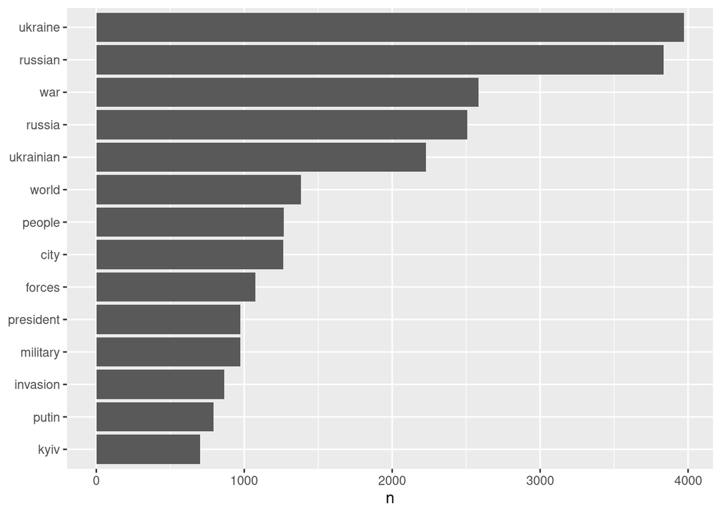

```r
tidy_articles %>%
  count(word, sort = TRUE) %>%
  filter(n > 700) %>%
  mutate(word = reorder(word, n)) %>%
  ggplot(aes(word, n)) +
  geom_col() +
  xlab(NULL) +
  coord_flip()
```

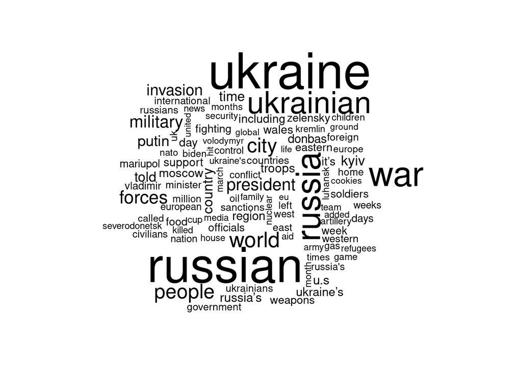

```r
tidy_articles %>%
  count(word) %>%
  with(wordcloud(word, n, max.words = 100))
```

```r
all_articles <- read_csv2("./data/all_ukraine_articles.csv")
```

## Sentiment analysis

Quando un umano legge un qualunque testo vi associa un sentimento, che viene ricavato dal significato delle parole. Non sempre il testo contiene emozioni positive o negative, possono anche esistere parti meno espressive. Useremo i tre *lexicon* già visti a lezione.

```r
get_sentiments("afinn") # da -5 a +5
```

```r
get_sentiments("bing") # positive e negative
```

```r
get_sentiments("nrc") # positive, negative, anger, anticipation, disgust, fear, joy, sadness, surprise e trust
```

```r
tidy_articles <- all_articles %>%
  unnest_tokens(word, body)

nrc_joy <- get_sentiments("nrc") %>%
  filter(sentiment == "joy")

tidy_articles %>%
  inner_join(nrc_joy) %>%
  count(word, sort = TRUE)
```

```
## # A tibble: 396 × 2
##    word             n
##    <chr>        <int>
##  1 food           457
##  2 found          190
##  3 victory        185
##  4 ministry       182
##  5 football       173
##  6 peace          173
##  7 humanitarian   164
##  8 good           152
##  9 money          150
## 10 intelligence   137
## # … with 386 more rows
```

Per ogni fonte, analizziamo il giorno con più articoli.

```r
tidy_articles_sentiment <- all_articles %>%
  group_by(source) %>%
  count(source, date, sort = TRUE) %>%
  top_n(1) %>%
  semi_join(all_articles, .) %>%
  ungroup() %>%
  unnest_tokens(word, body) %>%
  inner_join(get_sentiments("bing")) %>%
  count(source, date, sentiment) %>%
  pivot_wider(names_from = sentiment, values_from = n, values_fill = 0) %>%
  mutate(sentiment = positive - negative)

tidy_articles_sentiment
```

```
## # A tibble: 4 × 5
##   source     date       negative positive sentiment
##   <chr>      <date>        <int>    <int>     <int>
## 1 BBC        2022-06-03      726      314      -412
## 2 Guardian   2022-05-31      488      391       -97
## 3 LA Times   2022-04-20      207      139       -68
## 4 New Yorker 2022-03-02       40       20       -20
```

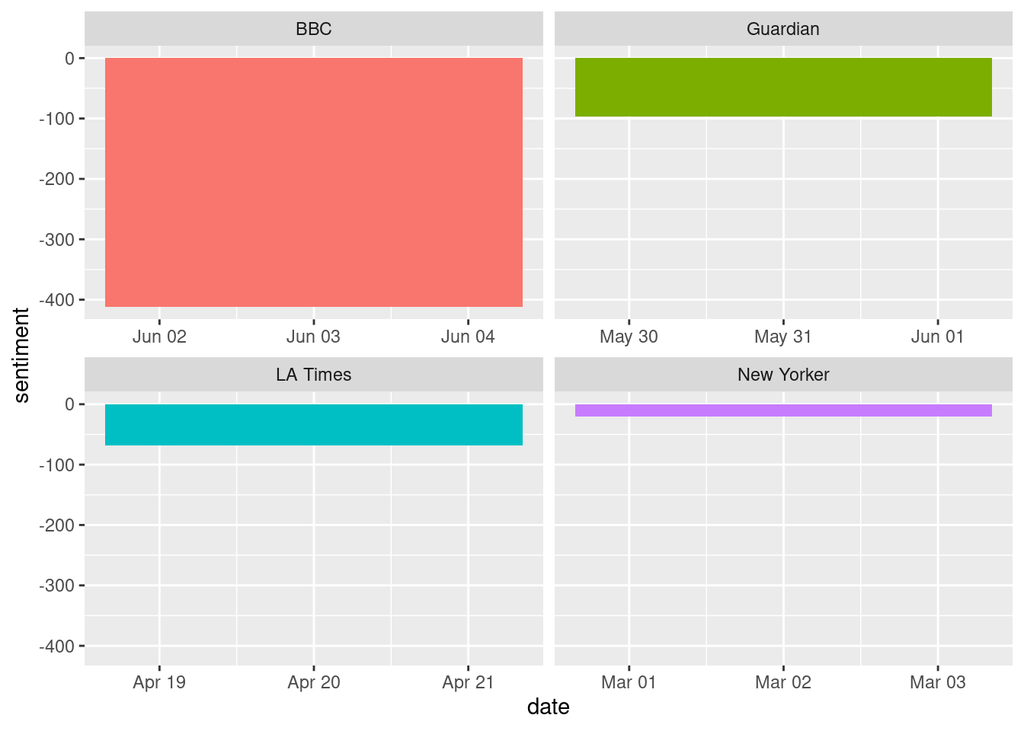

```r
ggplot(tidy_articles_sentiment, aes(date, sentiment, fill = source)) +
  geom_col(show.legend = FALSE) +
  facet_wrap(~source, ncol = 2, scales = "free_x")
```

Adesso confrontiamo i vari lexicon tra di loro. Utilizziamo solamente gli articoli della BBC.

```r
tidy_BBC <- tidy_articles %>%
  filter(source == "BBC")
tidy_BBC
```

```
## # A tibble: 180,823 × 5
##    source url                                          date       title    word
##    <chr>  <chr>                                        <date>     <chr>    <chr>
##  1 BBC    https://www.bbc.co.uk/news/uk-wales-61582902 2022-06-05 World C… we
##  2 BBC    https://www.bbc.co.uk/news/uk-wales-61582902 2022-06-05 World C… use
##  3 BBC    https://www.bbc.co.uk/news/uk-wales-61582902 2022-06-05 World C… cook…
##  4 BBC    https://www.bbc.co.uk/news/uk-wales-61582902 2022-06-05 World C… to
##  5 BBC    https://www.bbc.co.uk/news/uk-wales-61582902 2022-06-05 World C… give
##  6 BBC    https://www.bbc.co.uk/news/uk-wales-61582902 2022-06-05 World C… you
##  7 BBC    https://www.bbc.co.uk/news/uk-wales-61582902 2022-06-05 World C… the
##  8 BBC    https://www.bbc.co.uk/news/uk-wales-61582902 2022-06-05 World C… best
##  9 BBC    https://www.bbc.co.uk/news/uk-wales-61582902 2022-06-05 World C… onli…
## 10 BBC    https://www.bbc.co.uk/news/uk-wales-61582902 2022-06-05 World C… expe…
## # … with 180,813 more rows
```

```r
afinn <- tidy_BBC %>%
  inner_join(get_sentiments("afinn")) %>%
  group_by(date) %>%
  summarise(sentiment = sum(value)) %>%
  mutate(method = "AFINN")
afinn
```

```
## # A tibble: 22 × 3
##    date       sentiment method
##    <date>         <dbl> <chr>
##  1 2022-05-15      -256 AFINN
##  2 2022-05-16         9 AFINN
##  3 2022-05-17        11 AFINN
##  4 2022-05-18       112 AFINN
##  5 2022-05-19      -142 AFINN
##  6 2022-05-20      -181 AFINN
##  7 2022-05-21       -64 AFINN
##  8 2022-05-22       -36 AFINN
##  9 2022-05-23      -848 AFINN
## 10 2022-05-24      -315 AFINN
## # … with 12 more rows
```

```r
bing_and_nrc <- bind_rows(
  tidy_BBC %>%
    inner_join(get_sentiments("bing")) %>%
    mutate(method = "Bing"),
  tidy_BBC %>%
    inner_join(get_sentiments("nrc") %>%
                 filter(sentiment %in% c("positive", "negative"))
    ) %>%
    mutate(method = "NRC")
  ) %>%
  count(method, date, sentiment) %>%
  pivot_wider(names_from = sentiment,
              values_from = n,
              values_fill = 0) %>%
  mutate(sentiment = positive - negative)
bing_and_nrc
```

```
## # A tibble: 44 × 5
##    method date       negative positive sentiment
##    <chr>  <date>        <int>    <int>     <int>
##  1 Bing   2022-05-15      168       66      -102
##  2 Bing   2022-05-16       18       14        -4
##  3 Bing   2022-05-17       48       57         9
##  4 Bing   2022-05-18       93      128        35
##  5 Bing   2022-05-19      170       92       -78
##  6 Bing   2022-05-20      258      179       -79
##  7 Bing   2022-05-21       87       77       -10
##  8 Bing   2022-05-22       78       46       -32
##  9 Bing   2022-05-23      551      222      -329
## 10 Bing   2022-05-24      415      201      -214
## # … with 34 more rows
```

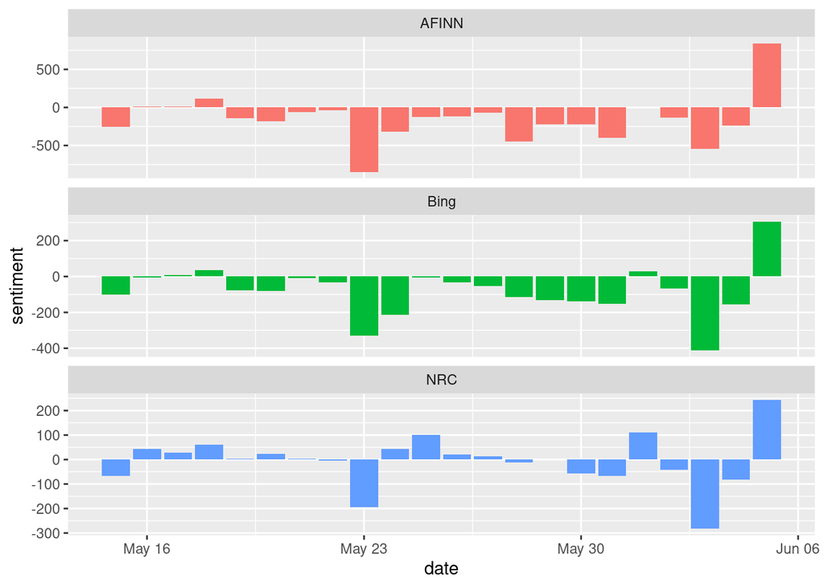

```r
bind_rows(afinn,
          bing_and_nrc) %>%
  ggplot(aes(date, sentiment, fill = method)) +
  geom_col(show.legend = FALSE) +
  facet_wrap(~method, ncol = 1, scales = "free_y")
```

Adesso possiamo prendere in considerazione le parole che hanno influito di più positivamente e negativamente.

```r
bing_word_counts <- tidy_articles %>%
  inner_join(get_sentiments("bing")) %>%
  count(word, sentiment, sort = TRUE) %>%
  ungroup()

bing_word_counts
```

```
## # A tibble: 2,615 × 3
##    word     sentiment     n
##    <chr>    <chr>     <int>
##  1 like     positive    650
##  2 support  positive    490
##  3 conflict negative    345
##  4 well     positive    323
##  5 killed   negative    283
##  6 right    positive    251
##  7 attack   negative    244
##  8 best     positive    241
##  9 work     positive    233
## 10 win      positive    215
## # … with 2,605 more rows
```

Vediamo il bar plot.

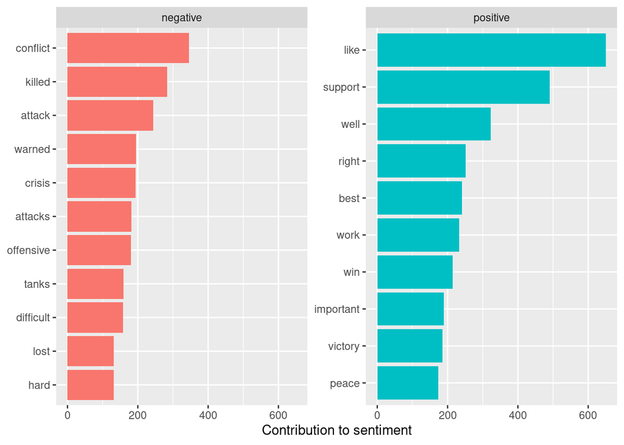

```r
bing_word_counts %>%
  group_by(sentiment) %>%
  slice_max(n, n = 10) %>%
  ungroup() %>%
  mutate(word = reorder(word, n)) %>%
  ggplot(aes(n, word, fill = sentiment)) +
  geom_col(show.legend = FALSE) +
  facet_wrap(~sentiment, scales = "free_y") +
  labs(x = "Contribution to sentiment",
       y = NULL)
```

Visti i tanti significati della parola like, è meglio escluderla dall’analisi.

```r
custom_stop_words <- bind_rows(tibble(word = c("like"),
                                      lexicon = c("project")),
                               stop_words)

custom_stop_words
```

```
## # A tibble: 1,150 × 2
##    word        lexicon
##    <chr>       <chr>
##  1 like        project
##  2 a           SMART
##  3 a's         SMART
##  4 able        SMART
##  5 about       SMART
##  6 above       SMART
##  7 according   SMART
##  8 accordingly SMART
##  9 across      SMART
## 10 actually    SMART
## # … with 1,140 more rows
```

```r
bing_word_counts <- bing_word_counts %>%
  anti_join(custom_stop_words)
bing_word_counts
```

```
## # A tibble: 2,582 × 3
##    word      sentiment     n
##    <chr>     <chr>     <int>
##  1 support   positive    490
##  2 conflict  negative    345
##  3 killed    negative    283
##  4 attack    negative    244
##  5 win       positive    215
##  6 warned    negative    195
##  7 crisis    negative    194
##  8 victory   positive    185
##  9 attacks   negative    182
## 10 offensive negative    180
## # … with 2,572 more rows
```

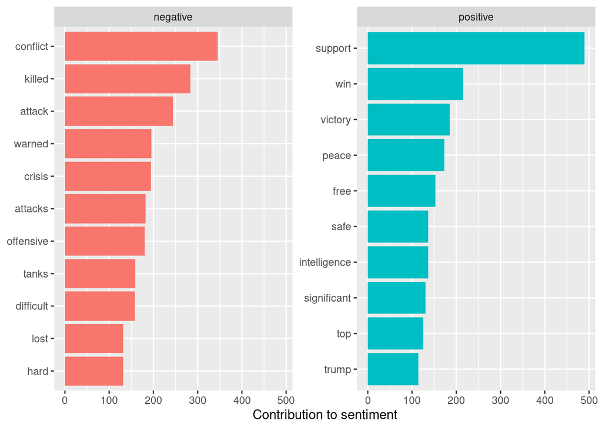

```r
bing_word_counts %>%
  group_by(sentiment) %>%
  slice_max(n, n = 10) %>%
  ungroup() %>%
  mutate(word = reorder(word, n)) %>%
  ggplot(aes(n, word, fill = sentiment)) +
  geom_col(show.legend = FALSE) +
  facet_wrap(~sentiment, scales = "free_y") +
  labs(x = "Contribution to sentiment",
       y = NULL)
```

## Word-cloud

Vediamo un word cloud in cui abbiamo diviso le parole in base al sentiment a loro associato.

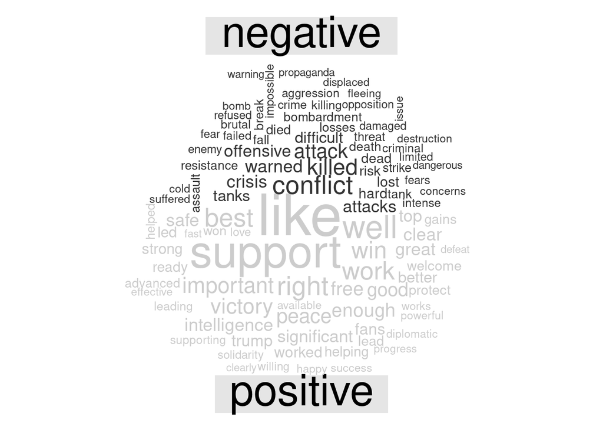

```r
library(reshape2)

tidy_articles %>%
  inner_join(get_sentiments("bing")) %>%
  count(word, sentiment, sort = TRUE) %>%
  acast(word ~ sentiment, value.var = "n", fill = 0) %>%
  comparison.cloud(colors = c("gray20", "gray80"),
                   max.words = 100)
```

## TF-IDF

La prossima misura che andremo ad analizzare è TF-IDF.

```r
articles_words <- all_articles %>%
  unnest_tokens(word, body) %>%
  count(source, word, sort = TRUE)

# numero totale di parole per ogni sorgente
total_words <- articles_words %>%
  group_by(source) %>%
  summarise(total = sum(n))

articles_words <- left_join(articles_words, total_words)

articles_words
```

```
## # A tibble: 40,928 × 4
##    source     word      n  total
##    <chr>      <chr> <int>  <int>
##  1 LA Times   the   11196 188158
##  2 BBC        the   10476 180823
##  3 Guardian   the    7676 122986
##  4 BBC        to     5787 180823
##  5 LA Times   of     5337 188158
##  6 LA Times   to     5267 188158
##  7 New Yorker the    4870  77302
##  8 BBC        of     4711 180823
##  9 LA Times   and    4652 188158
## 10 LA Times   in     4558 188158
## # … with 40,918 more rows
```

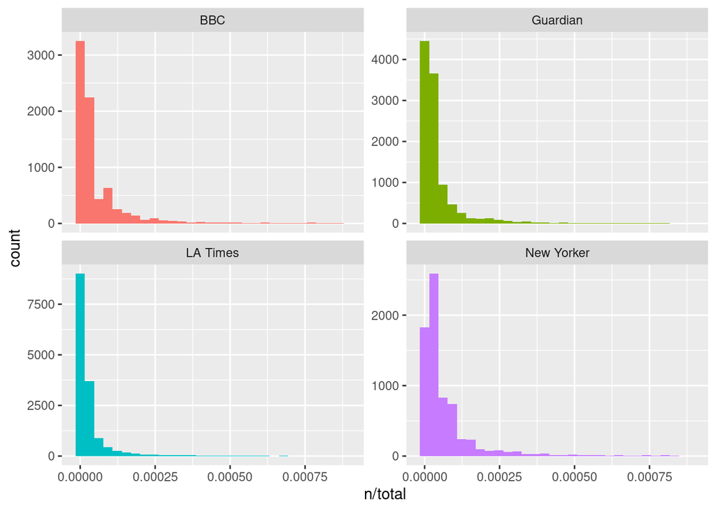

```r
ggplot(articles_words, aes(n/total, fill = source)) +
  geom_histogram(show.legend = FALSE) +
  xlim(NA, 0.0009) +
  facet_wrap(~source, ncol = 2, scales = "free_y")
```

Come si nota facilmente, abbiamo tante parole che si incontrano molto raramente (la coda lunga) e un numero limitato di parole che si leggono molto spesso.

## Zipf law

La legge di Zipf studia il rapporto tra il rango e la frequenza delle parole di un testo. In particolare:

> La legge di Zipf afferma che la frequenza di apparizione di una parola è inversamente proporzionale al suo rango.

Dove per rango si intende la posizione che la parola occupa in una classificazione delle parole basata sulla frequenza. La legge di Zipf ha una distribuzione Power-Law.

$$p_k = \alpha k^{-1}$$

$$p_k$$
è la frequenza della parola.
$$k$$
, invece, rappresenta il rango.
$$\alpha$$
è una costante.

```r
freq_by_rank <- articles_words %>%
  group_by(source) %>%
  mutate(rank = row_number(),
         `term frequency` = n/total)

freq_by_rank
```

```
## # A tibble: 40,928 × 6
## # Groups:   source [4]
##    source     word      n  total  rank `term frequency`
##    <chr>      <chr> <int>  <int> <int>            <dbl>
##  1 LA Times   the   11196 188158     1           0.0595
##  2 BBC        the   10476 180823     1           0.0579
##  3 Guardian   the    7676 122986     1           0.0624
##  4 BBC        to     5787 180823     2           0.0320
##  5 LA Times   of     5337 188158     2           0.0284
##  6 LA Times   to     5267 188158     3           0.0280
##  7 New Yorker the    4870  77302     1           0.0630
##  8 BBC        of     4711 180823     3           0.0261
##  9 LA Times   and    4652 188158     4           0.0247
## 10 LA Times   in     4558 188158     5           0.0242
## # … with 40,918 more rows
```

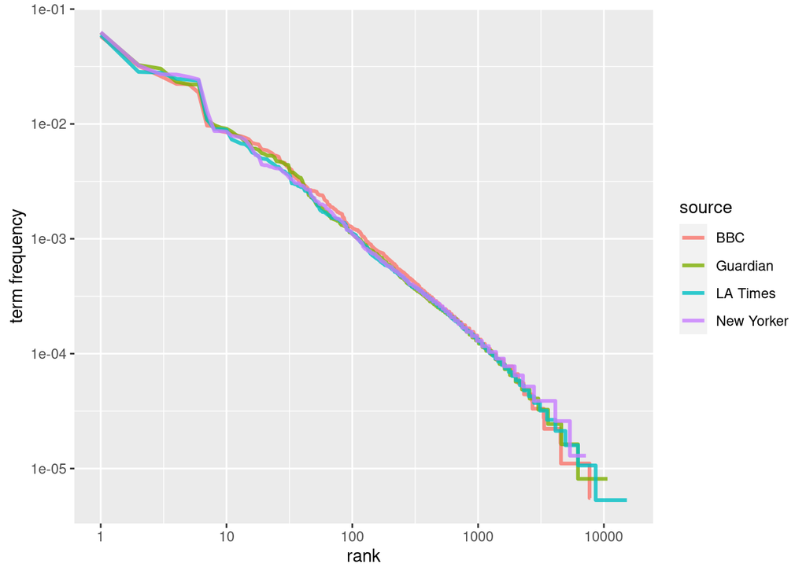

```r
freq_by_rank %>%
  ggplot(aes(rank, `term frequency`, group = source, color = source)) +
  geom_line(size = 1.1, alpha = 0.8, show.legend = TRUE) +
  scale_x_log10() +
  scale_y_log10()
```

La porzione di rango che va da 100 a 1000 sembra costante. Analizziamo questa sezione.

```r
rank_subset <- freq_by_rank %>%
  filter(rank < 1000,
         rank > 100)

mod = lm(log10(`term frequency`) ~ log10(rank), data = rank_subset)
mod
```

```
##
## Call:
## lm(formula = log10(`term frequency`) ~ log10(rank), data = rank_subset)
##
## Coefficients:
## (Intercept)  log10(rank)
##     -1.1222      -0.9163
```

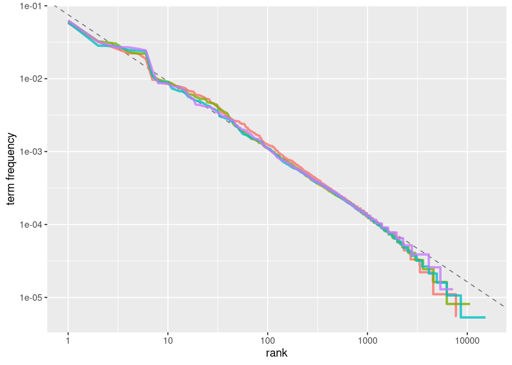

```r
freq_by_rank %>%
  ggplot(aes(rank, `term frequency`, color = source)) +
  geom_abline(intercept = mod$coefficients[1],
              slope = mod$coefficients[2],
              color = "gray50",
              linetype = 2) +
  geom_line(size = 1.1, alpha = 0.8, show.legend = FALSE) +
  scale_x_log10() +
  scale_y_log10()
```

Torniamo ad analizzare TF-IDF.

```r
articles_tf_idf <- articles_words %>%
  bind_tf_idf(word, source, n)

articles_tf_idf
```

```
## # A tibble: 40,928 × 7
##    source     word      n  total     tf   idf tf_idf
##    <chr>      <chr> <int>  <int>  <dbl> <dbl>  <dbl>
##  1 LA Times   the   11196 188158 0.0595     0      0
##  2 BBC        the   10476 180823 0.0579     0      0
##  3 Guardian   the    7676 122986 0.0624     0      0
##  4 BBC        to     5787 180823 0.0320     0      0
##  5 LA Times   of     5337 188158 0.0284     0      0
##  6 LA Times   to     5267 188158 0.0280     0      0
##  7 New Yorker the    4870  77302 0.0630     0      0
##  8 BBC        of     4711 180823 0.0261     0      0
##  9 LA Times   and    4652 188158 0.0247     0      0
## 10 LA Times   in     4558 188158 0.0242     0      0
## # … with 40,918 more rows
```

```r
articles_tf_idf %>%
  select(-total) %>%
  arrange(desc(tf_idf))
```

```
## # A tibble: 40,928 × 6
##    source     word                n       tf   idf   tf_idf
##    <chr>      <chr>           <int>    <dbl> <dbl>    <dbl>
##  1 BBC        russia's          347 0.00192  1.39  0.00266
##  2 BBC        it's              303 0.00168  1.39  0.00232
##  3 BBC        ukraine's         274 0.00152  1.39  0.00210
##  4 LA Times   u.s               487 0.00259  0.693 0.00179
##  5 Guardian   zelenskiy         125 0.00102  1.39  0.00141
##  6 New Yorker halima             76 0.000983 1.39  0.00136
##  7 Guardian   sievierodonetsk   106 0.000862 1.39  0.00119
##  8 BBC        cookies           254 0.00140  0.693 0.000974
##  9 BBC        welsh             216 0.00119  0.693 0.000828
## 10 New Yorker u.s                92 0.00119  0.693 0.000825
## # … with 40,918 more rows
```

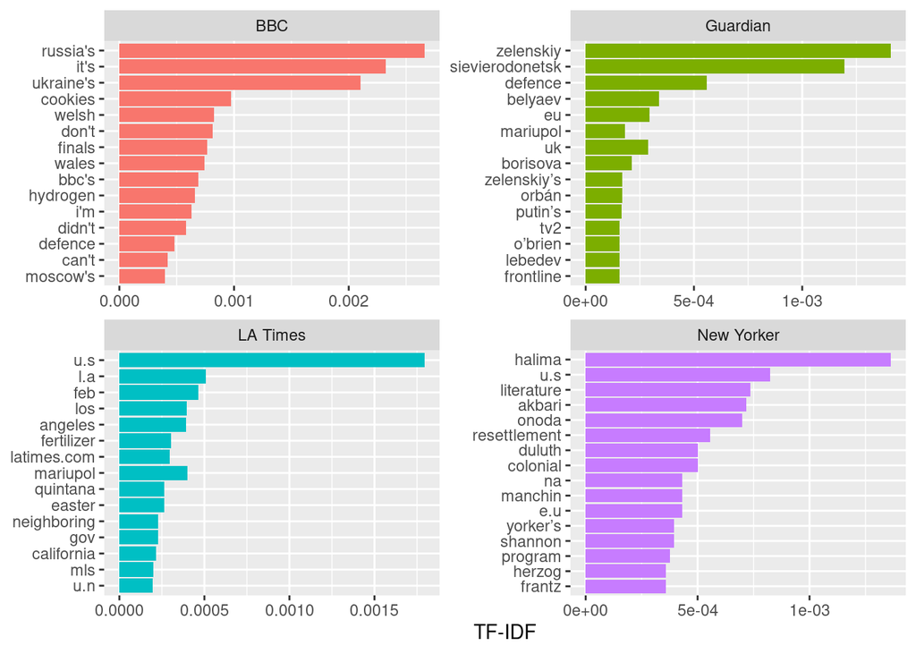

```r
articles_tf_idf %>%
  group_by(source) %>%
  slice_max(tf_idf, n = 15) %>%
  ungroup() %>%
  ggplot(aes(tf_idf, reorder(word, tf_idf), fill = source)) +
  geom_col(show.legend = FALSE) +
  facet_wrap(~source, ncol = 2, scales = "free") +
  labs(x = "TF-IDF", y = NULL)
```

## Bigram analysis

Come già fatto a lezione, procediamo ad analizzare i bigrammi, cioè gruppi di due parole consecutive. Come vedremo, i bigrammi ci torneranno particolarmente utili nella sentiment analysis, in quanto permettono di identificare le negazioni nel testo.

```r
articles_bigrams <- all_articles %>%
  unnest_tokens(bigram, body, token = "ngrams", n = 2)

articles_bigrams
```

```
## # A tibble: 568,606 × 5
##    source   url                                          date       title bigram
##    <chr>    <chr>                                        <date>     <chr> <chr>
##  1 Guardian https://www.theguardian.com/world/live/2022… 2022-06-02 Russ… ukrai…
##  2 Guardian https://www.theguardian.com/world/live/2022… 2022-06-02 Russ… presi…
##  3 Guardian https://www.theguardian.com/world/live/2022… 2022-06-02 Russ… claim…
##  4 Guardian https://www.theguardian.com/world/live/2022… 2022-06-02 Russ… 200,0…
##  5 Guardian https://www.theguardian.com/world/live/2022… 2022-06-02 Russ… child…
##  6 Guardian https://www.theguardian.com/world/live/2022… 2022-06-02 Russ… have …
##  7 Guardian https://www.theguardian.com/world/live/2022… 2022-06-02 Russ… been …
##  8 Guardian https://www.theguardian.com/world/live/2022… 2022-06-02 Russ… force…
##  9 Guardian https://www.theguardian.com/world/live/2022… 2022-06-02 Russ… taken…
## 10 Guardian https://www.theguardian.com/world/live/2022… 2022-06-02 Russ… to ru…
## # … with 568,596 more rows
```

```r
articles_bigrams %>%
  count(bigram, sort = TRUE)
```

```
## # A tibble: 184,457 × 2
##    bigram          n
##    <chr>       <int>
##  1 of the       3629
##  2 in the       3390
##  3 to the       1731
##  4 on the       1257
##  5 the war      1073
##  6 in a         1004
##  7 for the       925
##  8 at the        868
##  9 the russian   868
## 10 and the       861
## # … with 184,447 more rows
```

Rimuoviamo le stop words.

```r
bigrams_separated <- articles_bigrams %>%
  separate(bigram, c("word1", "word2"), sep = " ")

bigrams_filtered <- bigrams_separated %>%
  filter(!word1 %in% stop_words$word) %>%
  filter(!word2 %in% stop_words$word)

bigram_counts <- bigrams_filtered %>%
  count(word1, word2, sort = TRUE)

bigram_counts
```

```
## # A tibble: 56,203 × 3
##    word1     word2         n
##    <chr>     <chr>     <int>
##  1 russian   forces      479
##  2 world     cup         284
##  3 vladimir  putin       272
##  4 russian   troops      259
##  5 world     nation      226
##  6 president volodymyr   194
##  7 war       crimes      193
##  8 ukrainian forces      189
##  9 president vladimir    164
## 10 volodymyr zelensky    163
## # … with 56,193 more rows
```

```r
bigrams_united <- bigrams_filtered %>%
  unite(bigram, word1, word2, sep = " ")

bigrams_united
```

```
## # A tibble: 109,873 × 5
##    source   url                                          date       title bigram
##    <chr>    <chr>                                        <date>     <chr> <chr>
##  1 Guardian https://www.theguardian.com/world/live/2022… 2022-06-02 Russ… ukrai…
##  2 Guardian https://www.theguardian.com/world/live/2022… 2022-06-02 Russ… presi…
##  3 Guardian https://www.theguardian.com/world/live/2022… 2022-06-02 Russ… claim…
##  4 Guardian https://www.theguardian.com/world/live/2022… 2022-06-02 Russ… 200,0…
##  5 Guardian https://www.theguardian.com/world/live/2022… 2022-06-02 Russ… suppl…
##  6 Guardian https://www.theguardian.com/world/live/2022… 2022-06-02 Russ… mediu…
##  7 Guardian https://www.theguardian.com/world/live/2022… 2022-06-02 Russ… range…
##  8 Guardian https://www.theguardian.com/world/live/2022… 2022-06-02 Russ… rocke…
##  9 Guardian https://www.theguardian.com/world/2022/jun/… 2022-06-02 Russ… agree…
## 10 Guardian https://www.theguardian.com/world/2022/jun/… 2022-06-02 Russ… reach…
## # … with 109,863 more rows
```

## Uno sguardo ai trigrammi

Possiamo anche dare uno sguardo a come volge l’analisi nel caso in cui si considerano trigrammi.

```r
all_articles %>%
  unnest_tokens(trigram, body, token = "ngrams", n = 3) %>%
  separate(trigram, c("word1", "word2", "word3"), sep = " ") %>%
  filter(!word1 %in% stop_words$word) %>%
  filter(!word2 %in% stop_words$word) %>%
  filter(!word3 %in% stop_words$word) %>%
  count(word1, word2, word3, sort = TRUE)
```

```
## # A tibble: 29,374 × 4
##    word1     word2     word3         n
##    <chr>     <chr>     <chr>     <int>
##  1 president volodymyr zelensky    151
##  2 president vladimir  putin       142
##  3 russian   president vladimir    113
##  4 ukrainian president volodymyr    93
##  5 eastern   donbas    region       53
##  6 world     war       ii           52
##  7 cardiff   city      stadium      51
##  8 governor  serhiy    haidai       42
##  9 los       angeles   times        42
## 10 world     cup       finals       42
## # … with 29,364 more rows
```

```r
bigrams_filtered %>%
  filter(word1 == "zelensky") %>%
  count(source, word2, sort = TRUE)
```

```
## # A tibble: 76 × 3
##    source   word2       n
##    <chr>    <chr>   <int>
##  1 LA Times called     10
##  2 BBC      accused     6
##  3 BBC      called      4
##  4 BBC      told        4
##  5 BBC      urged       4
##  6 LA Times told        4
##  7 LA Times wrote       4
##  8 BBC      posted      3
##  9 LA Times accused     3
## 10 LA Times calls       3
## # … with 66 more rows
```

Diamo un’occhiata a TF-IDF, considerando un bigramma come fosse una parola.

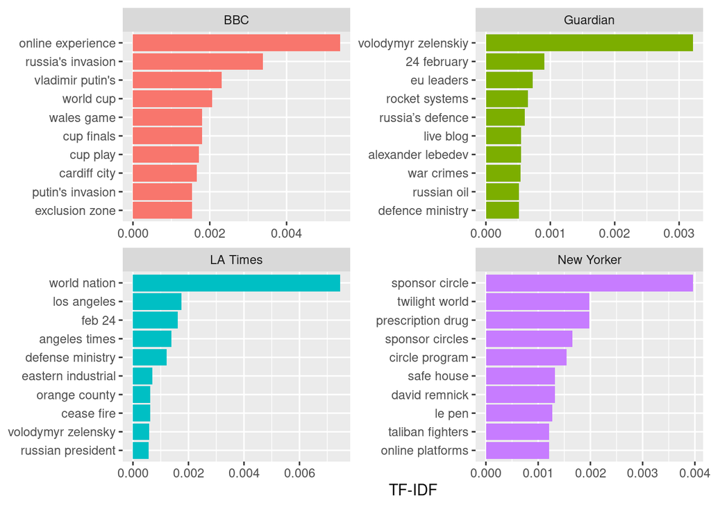

```r
bigram_tf_idf <- bigrams_united %>%
  count(source, bigram) %>%
  bind_tf_idf(bigram, source, n) %>%
  arrange(desc(tf_idf))

bigram_tf_idf %>%
  group_by(source) %>%
  slice_max(tf_idf, n = 10) %>%
  ungroup() %>%
  ggplot(aes(tf_idf, reorder(bigram, tf_idf), fill = source)) +
  geom_col(show.legend = FALSE) +
  facet_wrap(~source, ncol = 2, scales = "free") +
  labs(x = "TF-IDF", y = NULL)
```

## Bigram sentiment analysis

```r
bigrams_separated %>%
  filter(word1 == "not") %>%
  count(word1, word2, sort = TRUE)
```

```
## # A tibble: 532 × 3
##    word1 word2     n
##    <chr> <chr> <int>
##  1 not   to      142
##  2 not   be      130
##  3 not   a        66
##  4 not   only     50
##  5 not   the      50
##  6 not   been     47
##  7 not   just     47
##  8 not   have     39
##  9 not   yet      35
## 10 not   going    30
## # … with 522 more rows
```

```r
not_words <- bigrams_separated %>%
  filter(word1 == "not") %>%
  inner_join(get_sentiments("afinn"), by = c(word2 = "word")) %>%
  count(word2, value, sort = TRUE)

not_words
```

```
## # A tibble: 94 × 3
##    word2      value     n
##    <chr>      <dbl> <int>
##  1 want           1    30
##  2 humiliated    -3    14
##  3 clear          1    12
##  4 stop          -1    10
##  5 like           2     8
##  6 win            4     7
##  7 agree          1     6
##  8 allow          1     6
##  9 delayed       -1     6
## 10 eager          2     6
## # … with 84 more rows
```

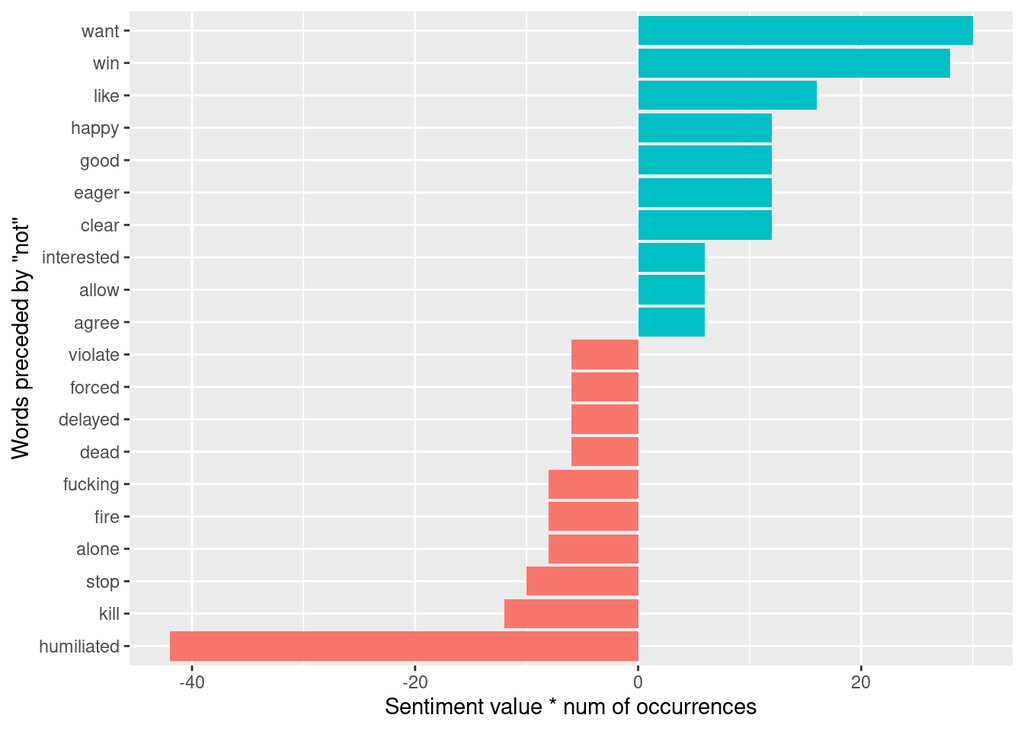

```r
not_words %>%
  mutate(contribution = n * value) %>%
  arrange(desc(abs(contribution))) %>%
  head(20) %>%
  mutate(word2 = reorder(word2, contribution)) %>%
  ggplot(aes(n * value, word2, fill = n * value > 0)) +
  geom_col(show.legend = FALSE) +
  labs(x = "Sentiment value * num of occurrences",
       y = "Words preceded by \"not\"")
```

## Negative words

```r
negation_words <- c("no", "not", "none", "noone", "nobody", "nothing", "neither", "nowhere", "never", "without")

negated_words <- bigrams_separated %>%
  filter(word1 %in% negation_words) %>%
  inner_join(get_sentiments("afinn"), by = c(word2 = "word")) %>%
  count(word1, word2, value, sort = TRUE)
negated_words
```

```
## # A tibble: 172 × 4
##    word1 word2      value     n
##    <chr> <chr>      <dbl> <int>
##  1 not   want           1    30
##  2 no    matter         1    19
##  3 no    fan            3    14
##  4 not   humiliated    -3    14
##  5 not   clear          1    12
##  6 not   stop          -1    10
##  7 no    no            -1     9
##  8 not   like           2     8
##  9 no    doubt         -1     7
## 10 not   win            4     7
## # … with 162 more rows
```

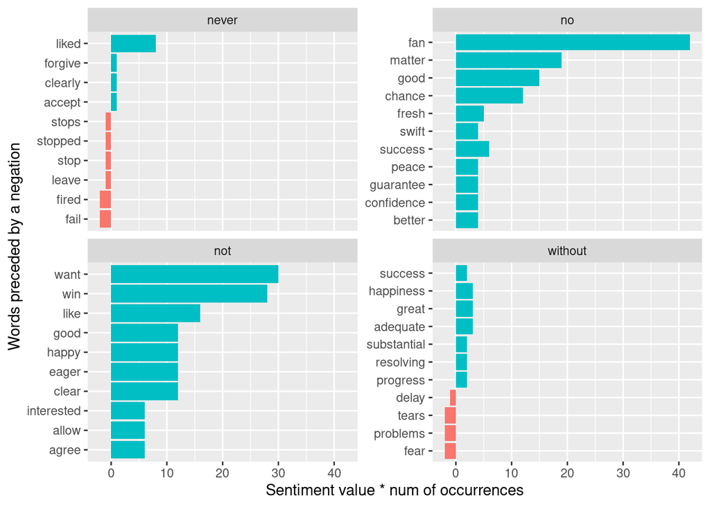

```r
negated_words %>%
  group_by(word1) %>%
  count() %>%
  filter(n >= 10) %>%
  semi_join(negated_words, ., by = "word1") %>%
  ungroup() %>%
  mutate(contribution = n * value) %>%
  arrange(desc(abs(contribution))) %>%
  group_by(word1) %>%
  top_n(contribution, n = 10) %>%
  ungroup() %>%
  mutate(word2 = reorder(word2, contribution)) %>%
  ggplot(aes(n * value, word2, fill = n * value > 0)) +
  geom_col(show.legend = FALSE) +
  facet_wrap(~word1, ncol = 2, scales = "free_y") +
  labs(x = "Sentiment value * num of occurrences",
       y = "Words preceded by a negation")
```

## Graph representation

Possiamo utilizzare la libreria ggraph (e il pacchetto [igraph](https://www.igraph.org/)) per visualizzare le relazioni tra coppie di parole.

```r
# teniamo solamente le coppie più comuni
bigram_graph <- bigram_counts %>%
  filter(n >= 40) %>%
  graph_from_data_frame()

bigram_graph
```

```
## IGRAPH bfb2d2c DN-- 121 98 --
## + attr: name (v/c), n (e/n)
## + edges from bfb2d2c (vertex names):
##  [1] russian  ->forces     world    ->cup        vladimir ->putin
##  [4] russian  ->troops     world    ->nation     president->volodymyr
##  [7] war      ->crimes     ukrainian->forces     president->vladimir
## [10] volodymyr->zelensky   world    ->war        donbas   ->region
## [13] black    ->sea        prime    ->minister   foreign  ->minister
## [16] russian  ->soldiers   russian  ->president  eastern  ->ukraine
## [19] russian  ->invasion   online   ->experience los      ->angeles
## [22] russian  ->military   social   ->media      ukrainian->president
## + ... omitted several edges
```

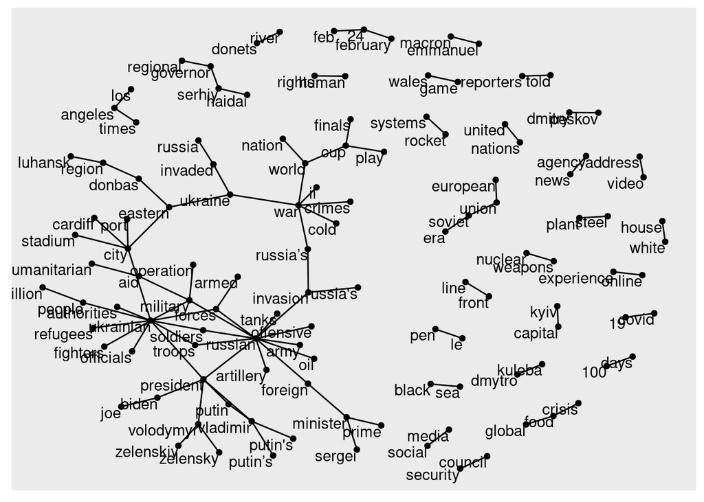

```r
set.seed(927)

ggraph(bigram_graph, layout = "fr") +
  geom_edge_link() +
  geom_node_point() +
  geom_node_text(aes(label = name), vjust = 1, hjust = 1)
```

Nel grafo si possono notare tante coppie di parole separate tra di loro (come nuclear - weapons, front - line, black - sea, etc.) e una grossa componente connessa. Parole come “ukrainian”, “russian”, “city” e “war” rappresentano centri comuni e vanno in coppia con tantissime altre parole.

Segue un’altra visualizzazione del grafo.

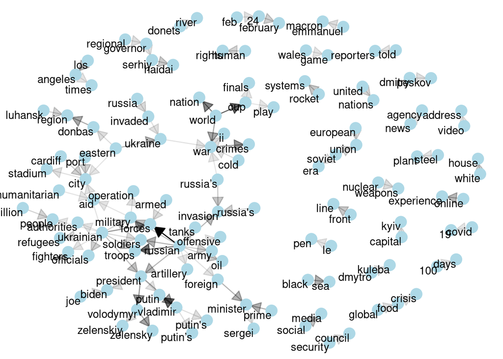

```r
set.seed(927)

a <- grid::arrow(type = "closed", length = unit(.15, "inches"))

ggraph(bigram_graph, layout = "fr") +
  geom_edge_link(aes(edge_alpha = n), show.legend = FALSE,
                 arrow = a, end_cap = circle(.07, 'inches')) +
  geom_node_point(color = "lightblue", size = 5) +
  geom_node_text(aes(label = name), vjust = 1, hjust = 1) +
  theme_void()
```

## Co-occurrencies and other statistics

Usiamo il package widyr per esplorare le co-occorrenze che avvengono tra documenti o parti di questi.

```r
all_articles_words <- all_articles %>%
  filter(source == "BBC") %>%
  # gruppi di dieci articoli
  mutate(group = row_number() %/% 10) %>%
  unnest_tokens(word, body) %>%
  filter(!word %in% stop_words$word)

all_articles_words
```

```
## # A tibble: 81,561 × 6
##    source url                                       date       title group word
##    <chr>  <chr>                                     <date>     <chr> <dbl> <chr>
##  1 BBC    https://www.bbc.co.uk/news/uk-wales-6158… 2022-06-05 Worl…     0 cook…
##  2 BBC    https://www.bbc.co.uk/news/uk-wales-6158… 2022-06-05 Worl…     0 onli…
##  3 BBC    https://www.bbc.co.uk/news/uk-wales-6158… 2022-06-05 Worl…     0 expe…
##  4 BBC    https://www.bbc.co.uk/news/uk-wales-6158… 2022-06-05 Worl…     0 agree
##  5 BBC    https://www.bbc.co.uk/news/uk-wales-6158… 2022-06-05 Worl…     0 cook…
##  6 BBC    https://www.bbc.co.uk/news/uk-wales-6158… 2022-06-05 Worl…     0 wales
##  7 BBC    https://www.bbc.co.uk/news/uk-wales-6158… 2022-06-05 Worl…     0 men's
##  8 BBC    https://www.bbc.co.uk/news/uk-wales-6158… 2022-06-05 Worl…     0 foot…
##  9 BBC    https://www.bbc.co.uk/news/uk-wales-6158… 2022-06-05 Worl…     0 team
## 10 BBC    https://www.bbc.co.uk/news/uk-wales-6158… 2022-06-05 Worl…     0 world
## # … with 81,551 more rows
```

```r
word_pairs <- all_articles_words %>%
  pairwise_count(word, group, sort = TRUE)

word_pairs
```

```
## # A tibble: 17,672,228 × 3
##    item1      item2       n
##    <chr>      <chr>   <dbl>
##  1 online     cookies    16
##  2 experience cookies    16
##  3 agree      cookies    16
##  4 world      cookies    16
##  5 ukraine    cookies    16
##  6 russia's   cookies    16
##  7 invasion   cookies    16
##  8 killed     cookies    16
##  9 ukrainian  cookies    16
## 10 uk         cookies    16
## # … with 17,672,218 more rows
```

Adesso prendiamo in considerazione la **correlazione** tra parole, che indica quanto spesso due parole appaiono insieme rispetto a quanto appaiono separate.

Il coefficiente phi indica quanto è probabile che le due parole (X e Y) appaiano insieme (o non appaiano insieme) rispetto a quanto una compaia senza l’altra.

|  | Y appare | Y non appare | Totale |  |
| --- | --- | --- | --- | --- |
| X appare | $n_{11}$ | $n_{10}$ | $n_{1\cdot}$ |  |
| X non appare | $n_{01}$ | $n_{00}$ | $n_{0\cdot}$ |  |
| Totale | $n_{\cdot 1}$ | $n_{\cdot 0}$ | $n$ |  |

$$\phi=\frac{n_{11}n_{00}-n_{10}n_{01}}{\sqrt{n_{1\cdot}n_{0\cdot}n_{\cdot0}n_{\cdot1}}}$$

```r
word_cor <- all_articles_words %>%
  group_by(word) %>%
  filter(n() >= 40) %>%
  pairwise_cor(word, group, sort = TRUE)

word_cor
```

```
## # A tibble: 124,962 × 3
##    item1   item2   correlation
##    <chr>   <chr>         <dbl>
##  1 24      ago               1
##  2 foreign ago               1
##  3 kremlin ago               1
##  4 weapons europe            1
##  5 europe  weapons           1
##  6 ago     24                1
##  7 foreign 24                1
##  8 kremlin 24                1
##  9 ago     foreign           1
## 10 24      foreign           1
## # … with 124,952 more rows
```

Le parole più correlate a “weapons”

```r
word_cor %>%
  filter(item1 == "weapons")
```

```
## # A tibble: 353 × 3
##    item1   item2      correlation
##    <chr>   <chr>            <dbl>
##  1 weapons europe           1
##  2 weapons leader           0.787
##  3 weapons systems          0.787
##  4 weapons equipment        0.787
##  5 weapons continue         0.655
##  6 weapons difficult        0.655
##  7 weapons major            0.655
##  8 weapons impossible       0.655
##  9 weapons final            0.561
## 10 weapons 22               0.561
## # … with 343 more rows
```

Vediamo lo stesso risultato anche per altre parole.

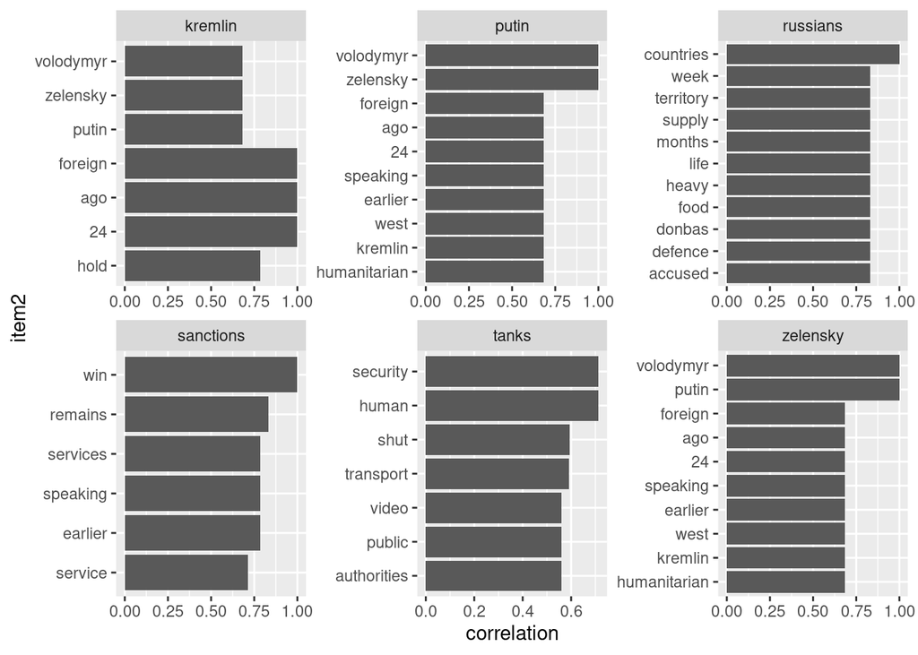

```r
word_cor %>%
  filter(item1 %in% c("putin", "zelensky", "kremlin", "tanks", "russians", "sanctions")) %>%
  group_by(item1) %>%
  slice_max(correlation, n = 6) %>%
  ungroup() %>%
  mutate(item2 = reorder(item2, correlation)) %>%
  ggplot(aes(item2, correlation)) +
  geom_bar(stat = "identity") +
  facet_wrap(~item1, scales = "free") +
  coord_flip()
```

Segue anche il grafo delle correlazioni. Valori di correlazione più alti sono indicati da un valore alto dell’attributo *edge_alpha*.

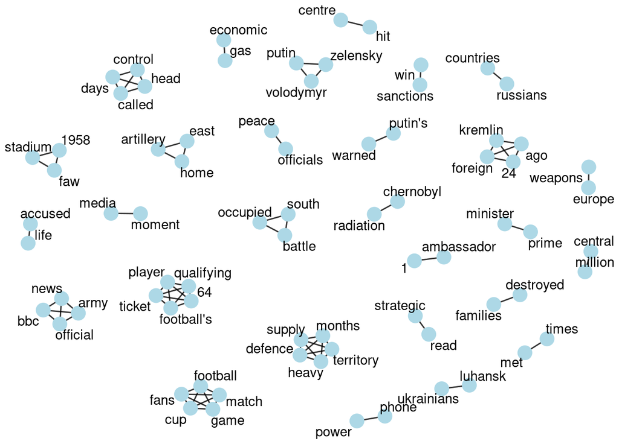

```r
set.seed(927)

word_cor %>%
  filter(correlation > 0.95) %>%
  graph_from_data_frame() %>%
  ggraph(layout = "fr") +
  geom_edge_link(aes(edge_alpha = correlation), show.legend = FALSE) +
  geom_node_point(color = "lightblue", size = 5) +
  geom_node_text(aes(label = name), repel = TRUE) +
  theme_void()
```